# Step 3. Preparing covariates

In this vignette, we will walk through the covariates. Our example considers the following covariates:

Additionally, we consider histories of treatment and outcomes as covariates. We generate histories of treatment and outcomes over previous 1, 7, and 30 days, and save them as columns of the hyperframe.

# 1 Covariates

## 1.1 The population (logged, in 2003) and settlement patterns

The data `ethnicity` is a collection of pixel images.

```r
ethnicity
```

```
#> $Shia
#> real-valued pixel image
#> 800 x 800 pixel array (ny, nx)
#> enclosing rectangle: [38.794, 48.628] x [29.061, 37.382] units
#>
#> $Sunni
#> real-valued pixel image
#> 800 x 800 pixel array (ny, nx)
#> enclosing rectangle: [38.794, 48.628] x [29.061, 37.382] units
#>
#> $Christians
#> real-valued pixel image
#> 800 x 800 pixel array (ny, nx)
#> enclosing rectangle: [38.794, 48.628] x [29.061, 37.382] units
#>
#> $Turcomans
#> real-valued pixel image
#> 800 x 800 pixel array (ny, nx)
#> enclosing rectangle: [38.794, 48.628] x [29.061, 37.382] units
#>
#> $Mixed_ShSu
#> real-valued pixel image
#> 800 x 800 pixel array (ny, nx)
#> enclosing rectangle: [38.794, 48.628] x [29.061, 37.382] units
#>
#> $total_pop
#> real-valued pixel image
#> 800 x 800 pixel array (ny, nx)
#> enclosing rectangle: [38.794, 48.628] x [29.061, 37.382] units
```

For each ethnic group (Shia, Sunni, Christians, Turcomans, and Shia/Sunni mixed), we have a map of settlement patterns.

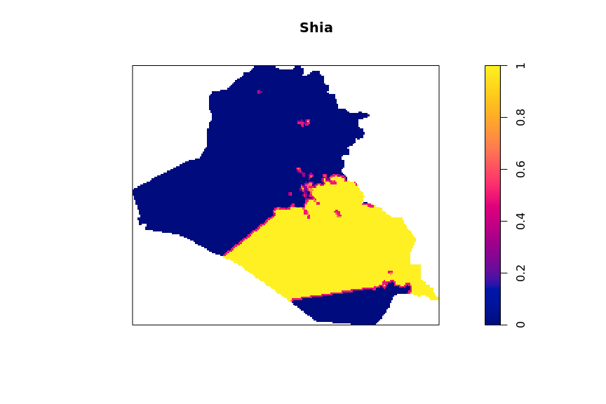

```r
plot(ethnicity$Shia, main = "Shia")
```

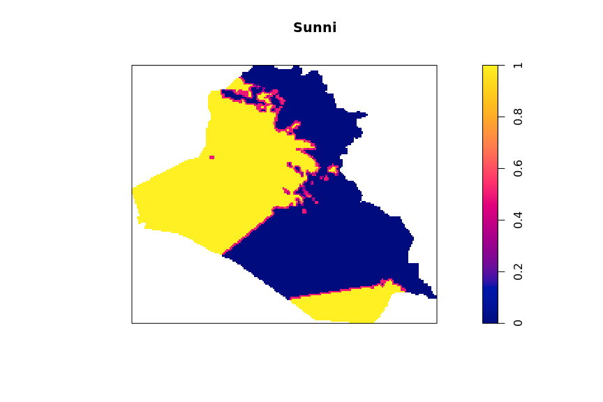

```r
plot(ethnicity$Sunni, main = "Sunni")
```

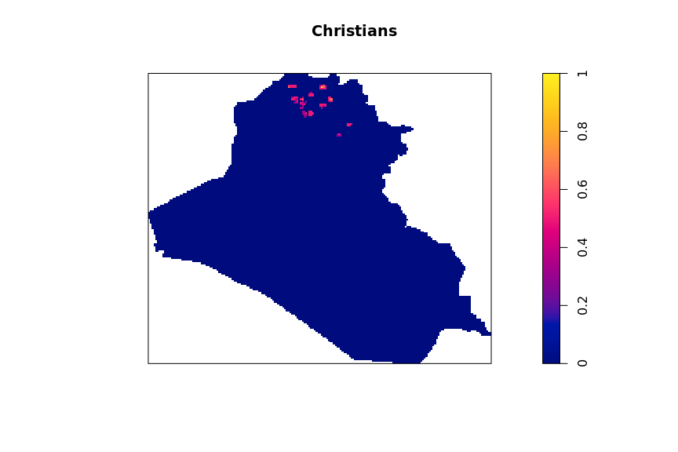

```r
plot(ethnicity$Christians, main = "Christians")
```

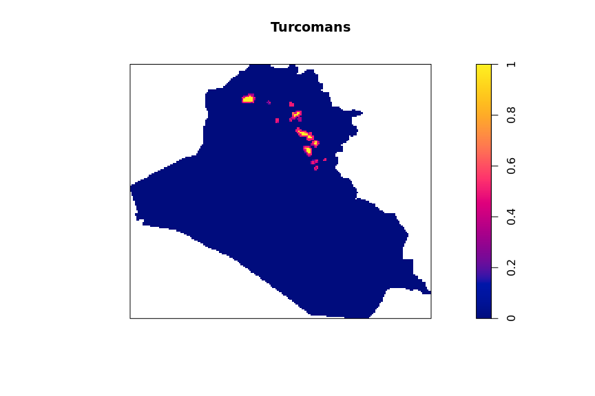

```r
plot(ethnicity$Turcomans, main = "Turcomans")
```

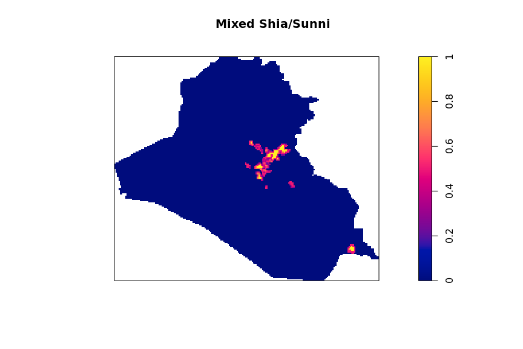

```r
plot(ethnicity$Mixed_ShSu, main = "Mixed Shia/Sunni")
```

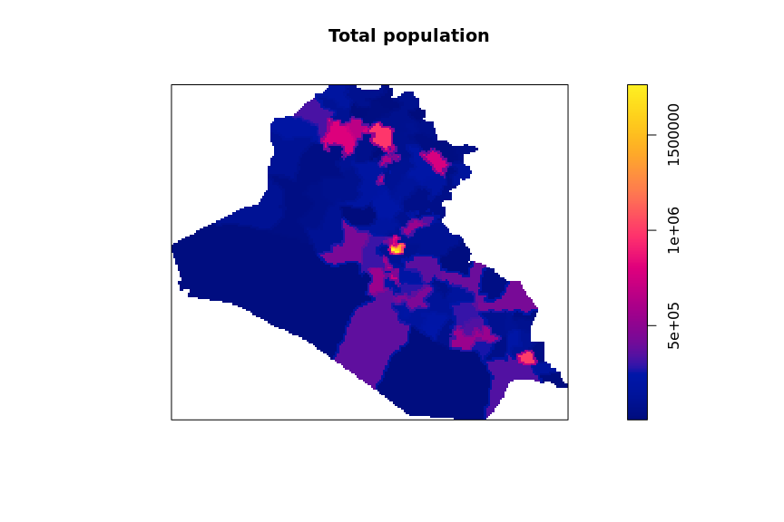

```r
plot(ethnicity$total_pop, main = "Total population")
```

Let’s save each of them as a separate column of the hyperframe.

```r
dat_hfr$Shia <- spatstat.geom::as.im(ethnicity$Shia, dimyx = 200)
dat_hfr$Sunni <- spatstat.geom::as.im(ethnicity$Sunni, dimyx = 200)
dat_hfr$Christians <- spatstat.geom::as.im(ethnicity$Christians, dimyx = 200)
dat_hfr$Turcomans <- spatstat.geom::as.im(ethnicity$Turcomans, dimyx = 200)
dat_hfr$MixedShSu <- spatstat.geom::as.im(ethnicity$Mixed_ShSu, dimyx = 200)
dat_hfr$logPopulation <- spatstat.geom::as.im(log(ethnicity$total_pop), dimyx = 200)
```

## 1.2 Distances from major cities

`cities_dist` is a hyperframe of point processes and pixel images.

```r
head(cities_dist)
```

```
#> Hyperframe:
#>                        Points distance
#> 1,000,000 to 5,000,000  (ppp)     (im)
#> 500,000 to 1,000,000    (ppp)     (im)
#> 250,000 to 500,000      (ppp)     (im)
#> 100,000 to 250,000      (ppp)     (im)
#> 50,000 to 100,000       (ppp)     (im)
#> Less than 50,000        (ppp)     (im)
```

The point processes summarize the locations of major cities based on the population size.

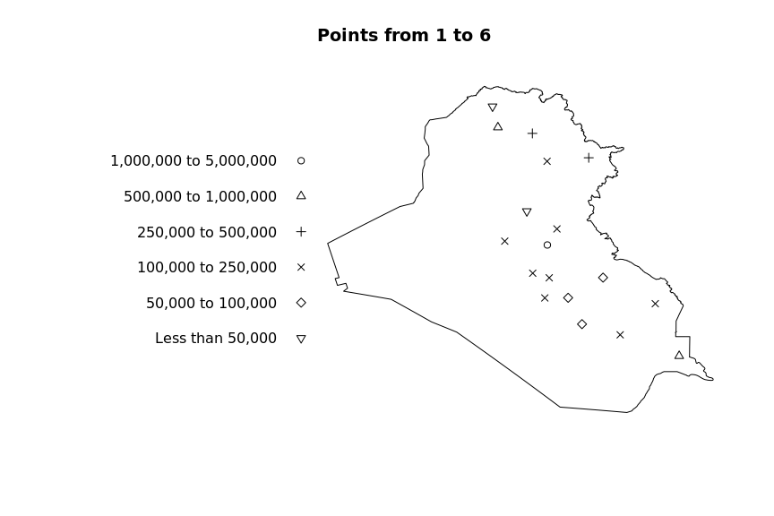

```
#> Symbol map for discrete inputs:
#> [1] "1,000,000 to 5,000,000" "500,000 to 1,000,000"   "250,000 to 500,000"
#> [4] "100,000 to 250,000"     "50,000 to 100,000"      "Less than 50,000"
#> chars: [1] 1 2 3 4 5 6
```

```r
vis_hfr(hfr = cities_dist,
        subtype_column = "Points",
        time_column = NA,
        range = c(1, 6),
        combined = TRUE)
```

The pixel images show the distances from major cities.

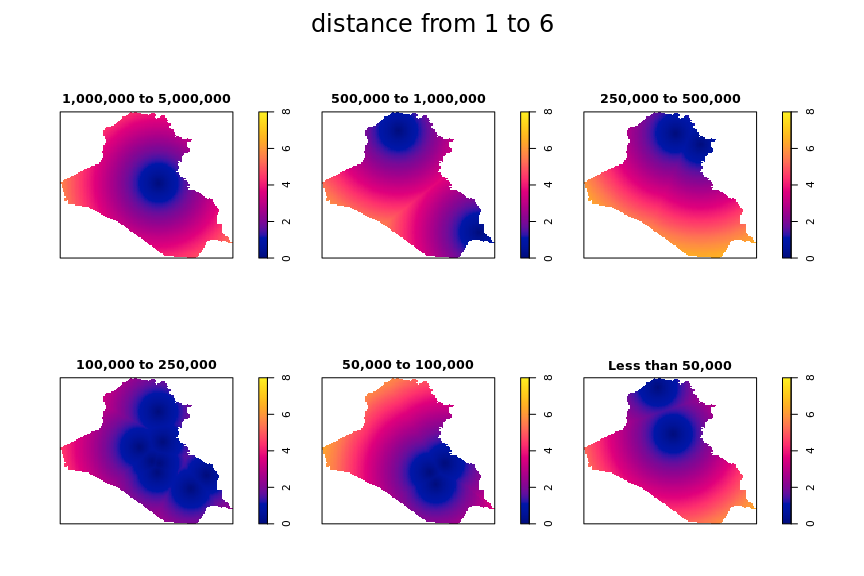

```r
vis_hfr(hfr = cities_dist,
        subtype_column = "distance",
        time_column = NA,
        range = c(1, 6),
        combined = FALSE,
        scale_max = 8)
```

We save these distances after multiplying by some constants and exponentiating them. We ignore small cities whose population < 50k. Additionally, we combine all five pixel images as one map and save it as a map that shows distances from all types of cities.

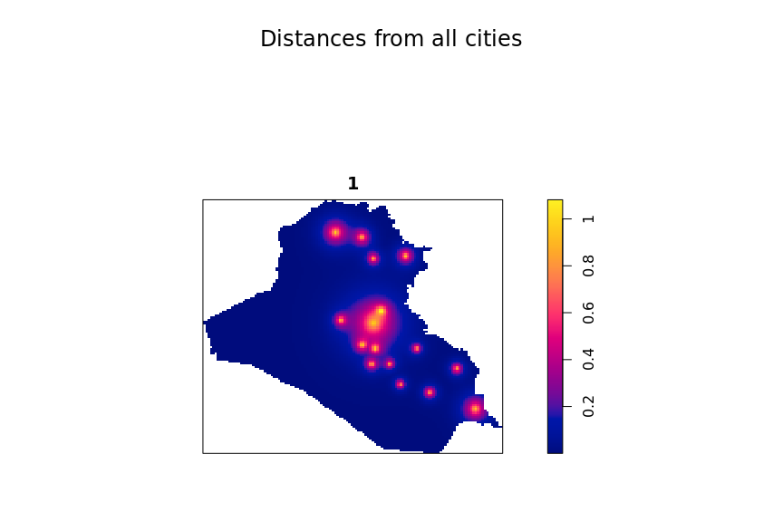

```r
covs <- c(2, 4, 6, 8, 10)

for (jj in 1 : 5) {
  dat_hfr$Extra <- exp(- covs[jj] * cities_dist$distance[[jj]])
  names(dat_hfr)[length(names(dat_hfr))] <- paste0("Cities.", jj)
}

dat_hfr$All_Cities <- dat_hfr$Cities.1 + dat_hfr$Cities.2 + dat_hfr$Cities.3 +
  dat_hfr$Cities.4 + dat_hfr$Cities.5

plot(dat_hfr$All_Cities[1], main = "Distances from all cities")
```

## 1.3 Distances from rivers

`rivers_dist` is a pixel image that shows distances from major rivers.

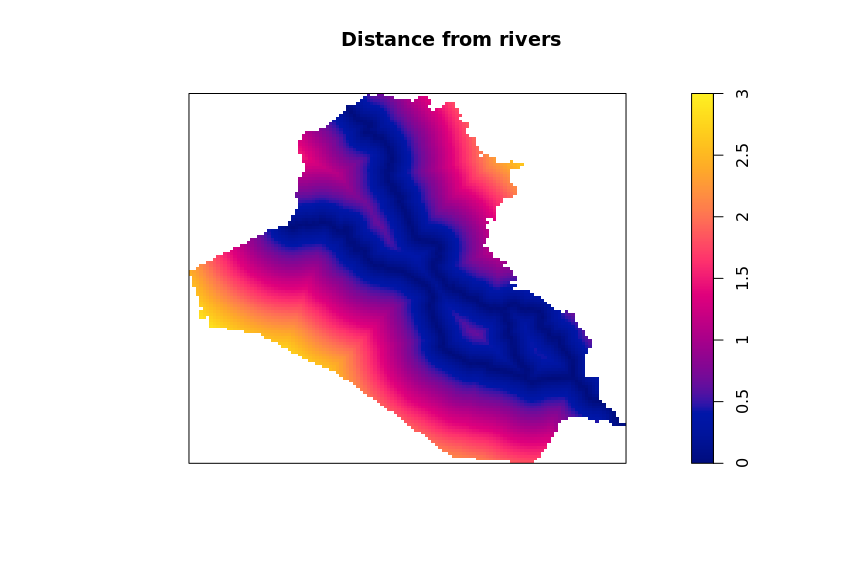

```r
plot(rivers_dist, main = "Distance from rivers", zlim = c(0, 3))
```

Let’s save it as a column of the hyperframe. For purely visualization purposes, we multiply the distances by -3 and then exponentiate it before saving it.

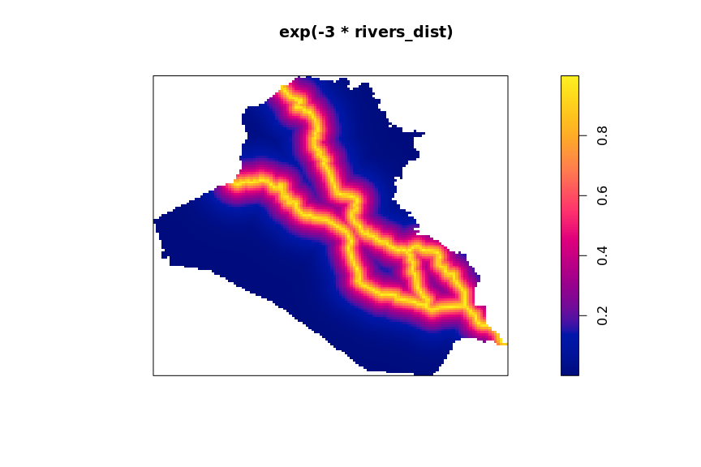

```r
plot(exp(- 3 * rivers_dist))
```

```r
dat_hfr$prior_rivers <- exp(- 3 * rivers_dist)
```

## 1.4 Distances from roads

`routes_dist` is also a pixel image that shows distances from road networks.

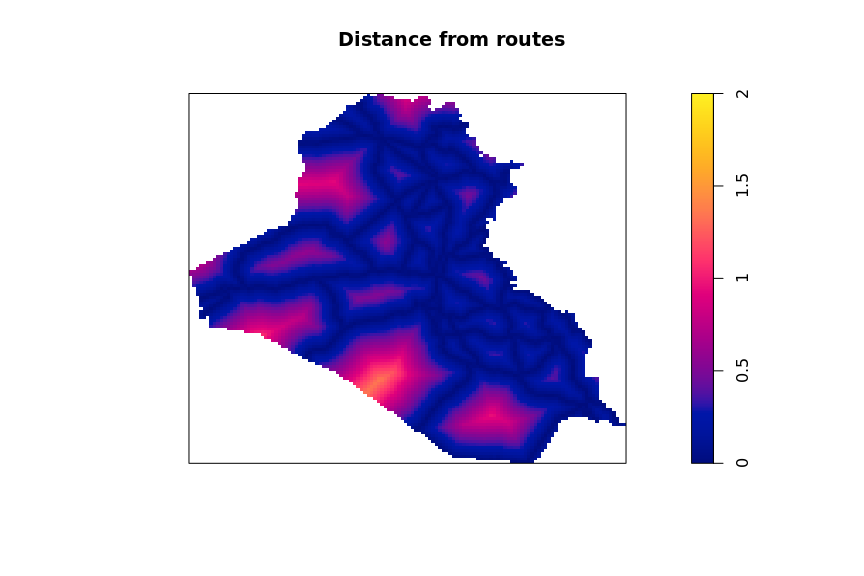

```r
plot(routes_dist, main = "Distance from routes", zlim = c(0, 2))
```

Similarly, save it as a column after multiplying it by -3 and exponentiating it.

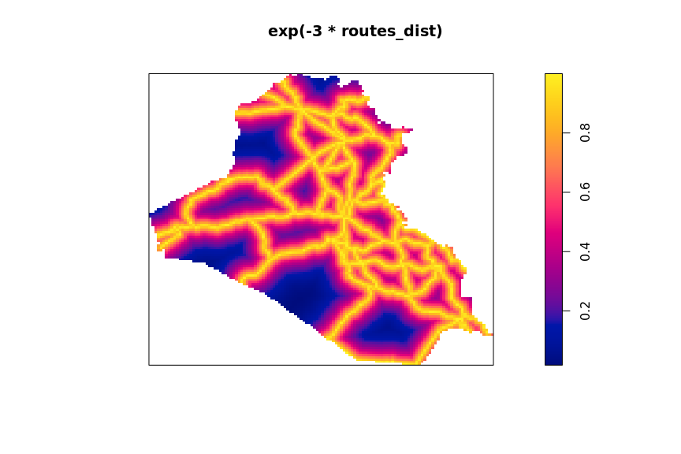

```r
plot(exp(-3 * routes_dist))
```

```r
dat_hfr$prior_roads <- exp(-3 * routes_dist)
```

## 1.5 Distances from settlements

The structure of `settle_dist` is similar to `cities_dist`. It is a hyperframe with point processes and pixel images.

```r
head(settle_dist)
```

```
#> Hyperframe:
#>        Points distance
#> IQ-G01  (ppp)     (im)
#> IQ-G02  (ppp)     (im)
#> IQ-G03  (ppp)     (im)
#> IQ-G04  (ppp)     (im)
#> IQ-G05  (ppp)     (im)
#> IQ-G06  (ppp)     (im)
```

The point processes show the locations of settlements in each Governorate in Iraq.

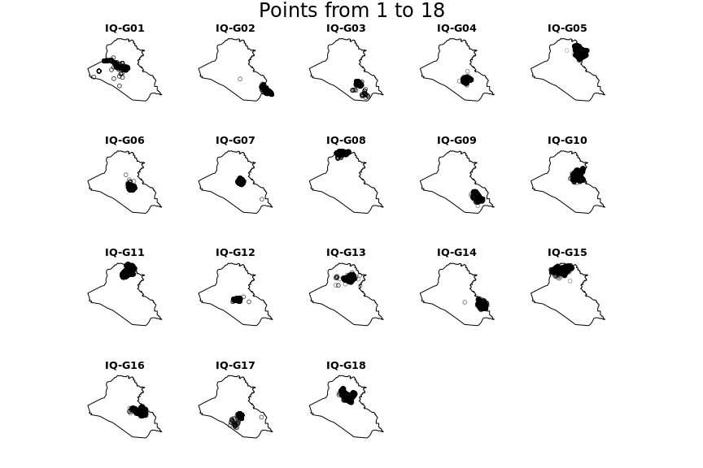

```r
vis_hfr(hfr = settle_dist,
        subtype_column = "Points",
        time_column = NA,
        range = c(1, 18),
        combined = FALSE)
```

Additionally, pixel images show the distances from the settlements.

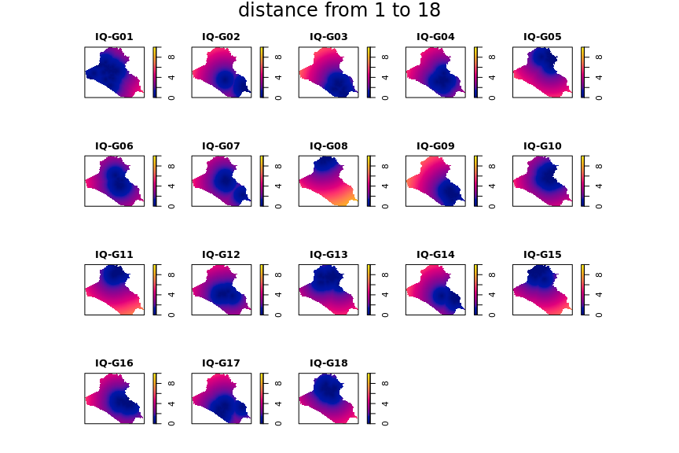

```r
vis_hfr(hfr = settle_dist,
        subtype_column = "distance",
        time_column = NA,
        range = c(1, 18),
        combined = FALSE,
        scale_max = 10)
```

We save each of these after multiplying by some constants and then exponentiating them.

```r
for (jj in 1 : 18) {
  dat_hfr$Extra <- exp(- 12 * settle_dist$distance[[jj]])
  col_name <- paste0('Settle.', rownames(settle_dist)[jj])
  names(dat_hfr)[length(names(dat_hfr))] <- col_name
}
```

## 1.6 The amount of aid spent (in U.S. dollars)

The aid data `aid_district` is summarized as the amount spent in the previous month in a district.

```r
head(aid_district)
```

```
#>          District   USE_DATE log_construct
#> 1: Abu Al-Khaseeb 2007-02-01      14.41272
#> 2: Abu Al-Khaseeb 2007-02-02      14.77334
#> 3: Abu Al-Khaseeb 2007-02-03      14.77334
#> 4: Abu Al-Khaseeb 2007-02-04      14.77334
#> 5: Abu Al-Khaseeb 2007-02-05      14.77334
#> 6: Abu Al-Khaseeb 2007-02-06      14.77334
```

We then convert it to pixel images.

```r
#iraq3 <- rgdal::readOGR(dsn = "~/geocausal/Data/covariates/Iraq Districts/.")
#dat_hfr$aid <- NULL #Modified

#get_aid_data <- function(dat_date) {
#  this_iraq3 <- iraq3
#  this_date <- dat_date
#  this_aid <- subset(aid_district, USE_DATE == this_date)
#  this_aid[, USE_DATE := NULL]
#  this_iraq3@data <- merge(this_iraq3@data, this_aid, by.x = "ADM3NAME",
#                           by.y = "District", all.x = TRUE)
#  this_iraq3@data$log_construct[is.na(this_iraq3@data$log_construct)] <- 0

#  r <- raster::raster(ncol = 128, nrow = 128)
#  raster::extent(r) <- raster::extent(this_iraq3)
#  rp <- raster::rasterize(this_iraq3, r, "log_construct")
#  rpim <- spatstat.geom::as.im(rp)
#  spatstat.geom::Window(rpim) <- iraq_window
#  return(rpim)
#}

#dat_hfr$aid <- furrr::future_map(dat_hfr$time, get_aid_data)
```

Each of pixel images is the summary of aid spending over the past one month in each district.

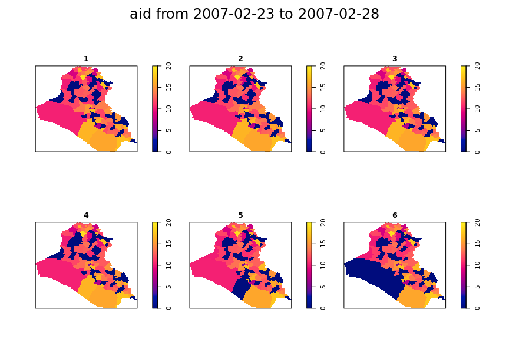

```r
dat_hfr <- readRDS("~/geocausal/Data/dat_hfr_3.rds")

vis_hfr(hfr = dat_hfr,
        subtype_column = "aid",
        time_column = "time",
        range = c("2007-02-23", "2007-02-28"),
        combined = FALSE,
        scale_max = 20)
```

## 1.7 Splines of time

Additionally, we have temporal splines as a covariate. This is the B-spline basis matrix for a natural cubic spline, using days (1 to 499) as predictors. We set the degree of freedom = 3.

```r
time_splines <- splines::ns(1 : nrow(dat_hfr), df = 3)
#for (jj in 1 : 3) {
#  dat_hfr$Extra <- time_splines[, jj]
#  names(dat_hfr)[ncol(dat_hfr)] <- paste0("time.", jj)
#}

head(time_splines)
```

```
#>                 1           2            3
#> [1,]  0.000000000 0.000000000  0.000000000
#> [2,] -0.001527335 0.004582114 -0.003054743
#> [3,] -0.003054356 0.009163942 -0.006109295
#> [4,] -0.004580749 0.013745199 -0.009163466
#> [5,] -0.006106201 0.018325599 -0.012217066
#> [6,] -0.007630397 0.022904856 -0.015269904
```

The values of each element look like as follows:

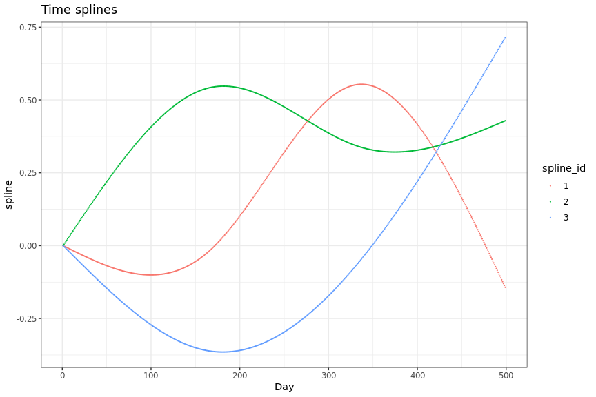

```r
data.frame(spline = c(time_splines[, 1], time_splines[, 2], time_splines[, 3]),
           spline_id = as.factor(c(rep(1, nrow(dat_hfr)),
                                   rep(2, nrow(dat_hfr)),
                                   rep(3, nrow(dat_hfr)))),
           Day = c(rep(1:nrow(dat_hfr), 3))) -> spline_data

ggplot(spline_data) +
  geom_point(aes(y = spline, x = Day, color = spline_id), size = 0.1) +
  theme_bw() +
  labs(title = "Time splines")
```